# Restricted Mean Survival Time in Practice

Implementation of RMST analysis

Angel Cronin, Xiang Meng, and Hajime Uno

**Software for implementation of RMST analysis covered in these 2 sessions**

| Use | R package | Stata package | SAS procedure |
| --- | --- | --- | --- |
| Unadjusted analysis | survRM2 | strmst2 | PROC LIFETEST |
| Adjusted analysis | survRM2 | strmst2 | PROC RMSTREG |
| Study design | SSRMST, RMSTDesign | n/a | n/a |
| Stratified analysis | StratSurv | n/a | n/a |

This training will use R, but slides illustrating implementation in Stata and SAS are included at the end.

**Setup (1 of 2):** These packages are required to run the example code.

```r
library(tidyverse)
library(survminer)
library(devtools)
devtools::install_github("uno1lab/survRM2")
library(survRM2)
```

**Notes**

- Install tidyverse, survminer, and devtools packages, if needed.
- The survRM2 package is also available for installation through CRAN. However, Hajime’s GitHub repo will have the most up-to-date version.

**Setup (2 of 2):** The examples use the Mayo Clinic Primary Biliary Cholangitis dataset.

After loading the data, we perform basic data manipulation to create the dataset used in the examples.

```r
data(pbc, package="survival")
df <- pbc %>%
  filter(!is.na(trt)) %>%
  mutate(status = if_else(status==2, 1, 0),
         arm = if_else(trt==1, 1, 0),
         time = time / 365.25) %>%
  select(id, time, status, arm, age, edema, bili, albumin, protime)
```

**Note**

If the survRM2 package is installed from GitHub, this edited dataset can be retrieved by **df <- rmst2.sample.data()**

Let’s take a look at the example data.

```r
head(df)
```

```
  id      time status arm      age edema bili albumin protime
1  1  1.095140      1   1 58.76523   1.0 14.5    2.60    12.2
2  2 12.320329      0   1 56.44627   0.0  1.1    4.14    10.6
3  3  2.770705      1   1 70.07255   0.5  1.4    3.48    12.0
4  4  5.270363      1   1 54.74059   0.5  1.8    2.54    10.3
5  5  4.117728      0   0 38.10541   0.0  3.4    3.53    10.9
6  6  6.852841      1   0 66.25873   0.0  0.8    3.98    11.0
```

Let’s use a Kaplan-Meier plot to review the survival probabilities and length of follow-up.

```r
ggsurvplot(survfit(Surv(time, status) ~ arm, data=df),
           data = df, legend.title = "",
           risk.table = TRUE,
           xlim = c(0, 14),
           break.x.by=2,
           ggtheme = theme_bw())
```

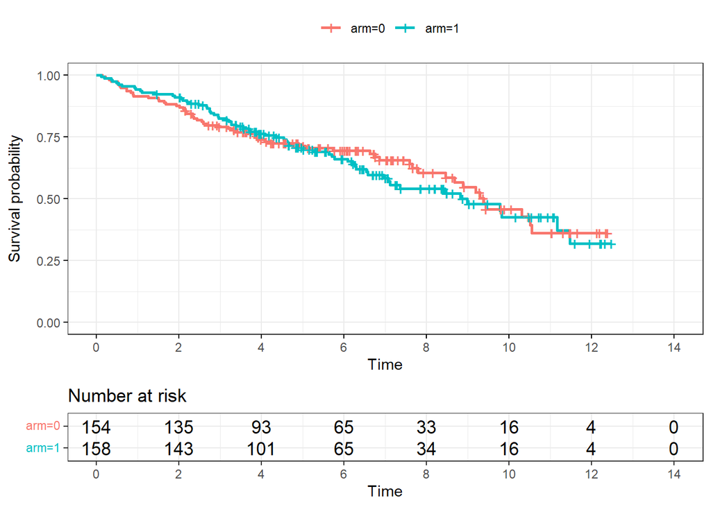

Let’s perform an unadjusted analysis of RMST by study arm, using a trunction timepoint of 10 years.

```r
result <- rmst2(time=df$time,     # analysis time
                status=df$status, # event indicator
                arm=df$arm,       # study arm (independent variable of interest)
                tau=10)           # truncation time
```

Table of summary statistics

```r
print(result)
```

```
The truncation time: tau = 10  was specified.

Restricted Mean Survival Time (RMST) by arm
              Est.    se lower .95 upper .95
RMST (arm=1) 7.146 0.283     6.592     7.701
RMST (arm=0) 7.283 0.295     6.704     7.863


Restricted Mean Time Lost (RMTL) by arm
              Est.    se lower .95 upper .95
RMTL (arm=1) 2.854 0.283     2.299     3.408
RMTL (arm=0) 2.717 0.295     2.137     3.296


Between-group contrast
                       Est. lower .95 upper .95     p
RMST (arm=1)-(arm=0) -0.137    -0.939     0.665 0.738
RMST (arm=1)/(arm=0)  0.981     0.878     1.096 0.738
RMTL (arm=1)/(arm=0)  1.050     0.787     1.402 0.738
```

Visualization of RMST and RMTL

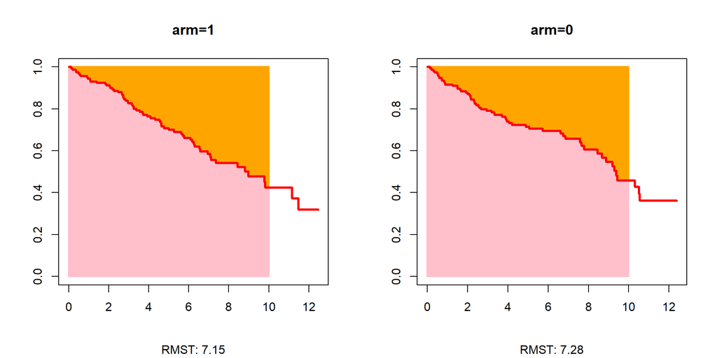

```r
plot(result)
```

## Interpretation

On average, when patients were followed up for 10 years, patients in the intervention group survived 7.146 years and patients in the control group survived 7.283 years (difference of -0.137 years for intervention vs control, 95% CI -0.939 to 0.665, p=0.738).

The ratio of RMST was 0.981 (95% CI 0.878 to 1.096) and the ratio of RMTL was 1.050 (95% CI 0.787 to 1.402).

**Logistical considerations for unadjusted analysis in R**

- Limited to two-sample comparisons; does not accommodate >2 groups
- Group variable must be coded as 0/1
- Summary table and plots will label the two groups as “arm 0” and “arm 1”, which may not be a good description of the group variable.

**Excercise: Treatment discontinuation example**

Schadendorf-OS.csv contains data reconstructed from a study of treatment discontinuation due to adverse events.

- time: observed time to death or censoring
- status: 1=dead, 0=censored
- arm: 1=discontinued, 0=did not discontinue

An investigator is interested in understanding the difference in RMST for overall survival between patients who discontinued versus patients who did not discontinue.

*Work on for 5-10 minutes and then we will review.*

**Treatment discontinuation example:**  
Let’s look at the data

```r
df <- read.csv("training_data/Schadendorf-OS.csv")
head(df)
```

```
  time status arm
1 1.11      1   1
2 2.59      1   1
3 3.00      1   1
4 3.43      1   1
5 3.52      1   1
6 4.14      1   1
```

**Treatment discontinuation example:**  
Let’s look at the Kaplan-Meier plot

```r
ggsurvplot(survfit(Surv(time, status) ~ arm, data=df),
           data = df, legend.title = "",
           risk.table = TRUE,
           xlim = c(0, 30),
           break.x.by=3,
           ggtheme = theme_bw())
```

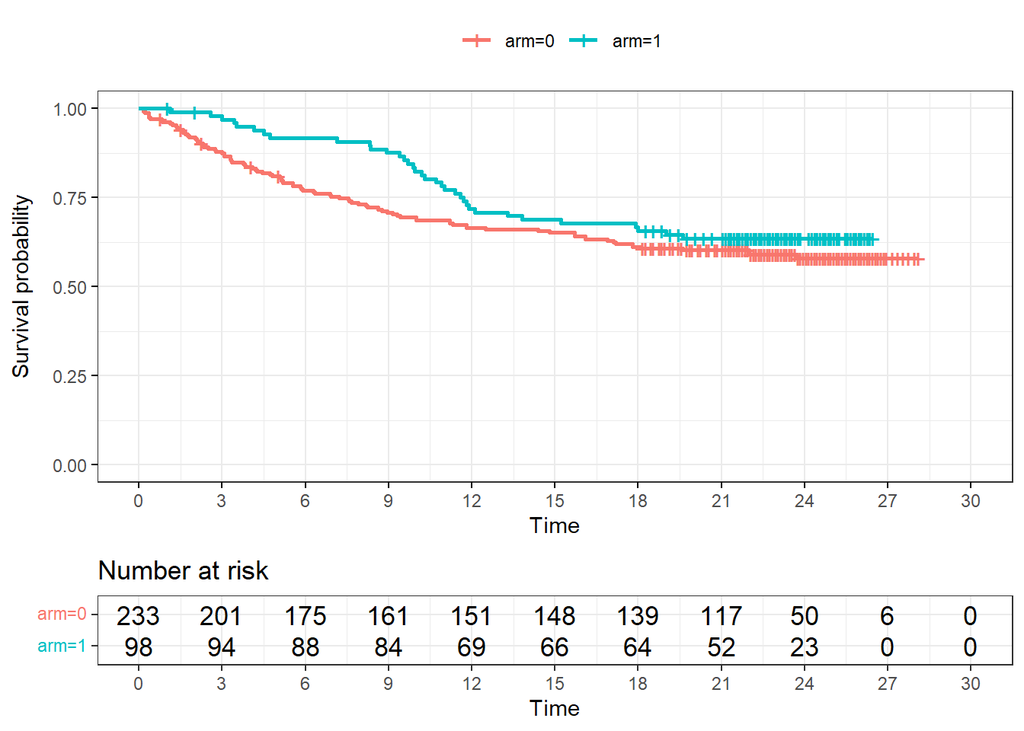

**Treatment discontinuation example:**  
Unadjusted analysis of RMST by study arm using a trunction timepoint of 12 months

```r
result12 <- rmst2(time=df$time,     # analysis time
                  status=df$status, # event indicator
                  arm=df$arm,       # study arm (independent variable of interest)
                  tau=12)           # truncation time
```

**Treatment discontinuation example:**  
Table of summary statistics (tau=12 months)

```r
print(result12)
```

```
The truncation time: tau = 12  was specified.

Restricted Mean Survival Time (RMST) by arm
               Est.    se lower .95 upper .95
RMST (arm=1) 10.915 0.252    10.420    11.409
RMST (arm=0)  9.554 0.259     9.046    10.061


Restricted Mean Time Lost (RMTL) by arm
              Est.    se lower .95 upper .95
RMTL (arm=1) 1.085 0.252     0.591     1.580
RMTL (arm=0) 2.446 0.259     1.939     2.954


Between-group contrast
                      Est. lower .95 upper .95     p
RMST (arm=1)-(arm=0) 1.361     0.652     2.069 0.000
RMST (arm=1)/(arm=0) 1.142     1.065     1.225 0.000
RMTL (arm=1)/(arm=0) 0.444     0.269     0.732 0.001
```

**Treatment discontinuation example:**  
Visualization of RMST and RMTL

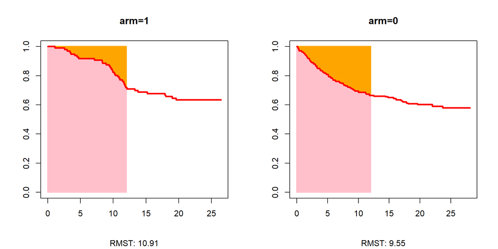

```r
plot(result12)
```

**Treatment discontinuation example:**  
Unadjusted analysis of RMST by study arm using a trunction timepoint of 24 months

```r
result24 <- rmst2(time=df$time,     # analysis time
                  status=df$status, # event indicator
                  arm=df$arm,       # study arm (independent variable of interest)
                  tau=24)           # truncation time
```

**Treatment discontinuation example:**  
Table of summary statistics (tau=24 months)

```r
print(result24)
```

```
The truncation time: tau = 24  was specified.

Restricted Mean Survival Time (RMST) by arm
               Est.    se lower .95 upper .95
RMST (arm=1) 18.876 0.746    17.415    20.338
RMST (arm=0) 17.026 0.604    15.843    18.210


Restricted Mean Time Lost (RMTL) by arm
              Est.    se lower .95 upper .95
RMTL (arm=1) 5.124 0.746     3.662     6.585
RMTL (arm=0) 6.974 0.604     5.790     8.157


Between-group contrast
                      Est. lower .95 upper .95     p
RMST (arm=1)-(arm=0) 1.850    -0.031     3.731 0.054
RMST (arm=1)/(arm=0) 1.109     0.999     1.230 0.052
RMTL (arm=1)/(arm=0) 0.735     0.527     1.024 0.069
```

**Treatment discontinuation example:**  
Visualization of RMST and RMTL

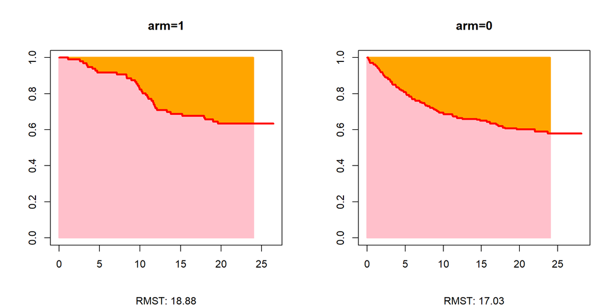

```r
plot(result24)
```

**Treatment discontinuation example:**  
**Interpretation**

Through **12 months** of follow-up, patients who discontinued survived an average of 10.9 months in comparison to 9.55 months for patients who did not discontinue (difference of 1.36 months, 95% CI 0.65 to 2.07, p<0.001).

Through **24 months** of follow-up, patients who discontinued survived an average of 18.9 months in comparison to 17.0 months for patients who did not discontinue (difference of 1.85 months, 95% CI -0.03 to 3.73, p=0.054).

**Summary of software for implementation of RMST analysis**

- Unadjusted analysis
  - R: survRM2::rmst2
  - Stata: -strmst2- from the strmst2 package
  - SAS: PROC LIFETEST
- Study Design, Adjusted Analysis and Stratified Analysis
  - Stay tuned (next week)

**References for software**

**R**  
https://github.com/uno1lab/survRM2  
https://cran.r-project.org/web/packages/survRM2/index.html

**Stata**  
https://ideas.repec.org/c/boc/bocode/s458154.html  
https://www.stata-journal.com/article.html?article=st0451

**SAS**  
https://documentation.sas.com/doc/en/statug/15.3/statug_lifetest_examples05.htm

## For reference: RMST analysis in **Stata**

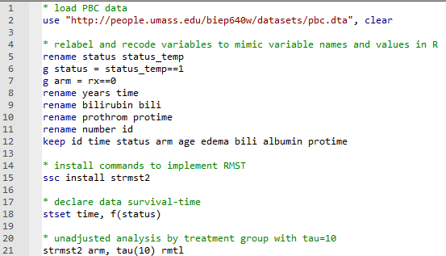

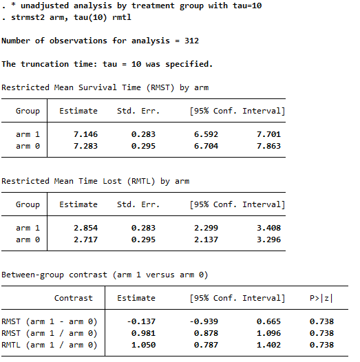

## For reference: RMST analysis in **SAS**

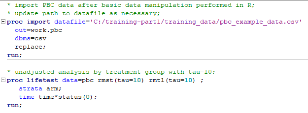

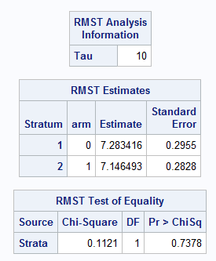

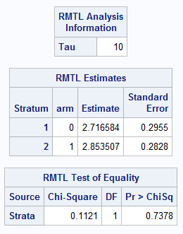

**Note**

PROC LIFETEST does not give a confidence interval for the RMST difference. You need to compute it manually using the estimated RMST difference +/- 1.96 x Standard Error. With this computation, all three software give the same results.